# 第3回 欠測値への対応や標準化など前処理の実行

データを整えて1泊の値段を付ける

# 導入

## 場面：民泊のホスト

① 場面●○

- あなたは、民泊を始めたばかりの新しいホスト
- 東京の自分のマンションの一室を、貸切で出したい
- 定員や寝室の数は、もう決まっている

## 決めたいこと

① 場面●●

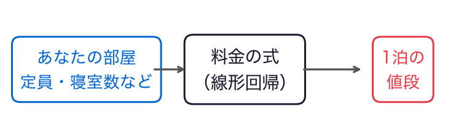

- 掲載するときの、1泊の値段を決めたい
- その値段がどれくらい外れうるかも知りたい

## 手元のデータ

② 手元のデータ●○

- Inside Airbnbが公開する、東京のAirbnbの掲載32,361件
- 1行が1つの部屋。地区・部屋のタイプ・定員・寝室数などが並ぶ
- 答えの列：その部屋の1泊の料金（円）

## データをのぞく

② 手元のデータ●●

|  | 地区 | 部屋のタイプ | 定員 | 寝室数 | ベッド数 | バスルームの表記 | 料金 |
| --- | --- | --- | --- | --- | --- | --- | --- |
| 0 | Nishitokyo Shi | Entire home/apt | 11 | 3.0 | 9.0 | 2 baths | 49000 |
| 1 | Kodaira Shi | Entire home/apt | 2 | 1.0 | 1.0 | 1 bath | 9648 |
| 2 | Sumida Ku | Private room | 2 | 1.0 | 1.0 | 1 shared bath | 5500 |
| 3 | Shinjuku Ku | Entire home/apt | 2 | 1.0 | 1.0 | 1 bath | 19100 |
| 4 | Itabashi Ku | Shared room | 1 | NaN | 4.0 | 1 shared bath | 4416 |

- 地区・部屋のタイプは文字の列。NaNは空欄（欠測値）

## 第2回のデータとの違い

③ 困りごと●○

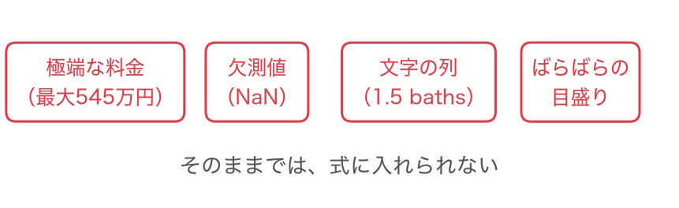

- 自転車のデータは、欠測もなく、どの列も数だった
- 今日のデータには、4つの困りごとが混ざる

## そのままでは式に入らない

③ 困りごと●●

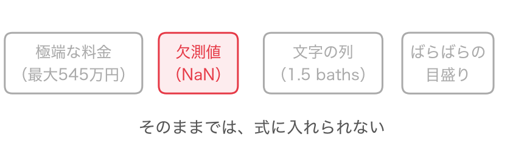

- とくに、欠測値があると、線形回帰の式は作れない
- データを、式に入れられる形に整える。これを前処理と呼ぶ

## 最後に出す答え

④ 今日の問い●○○○○○

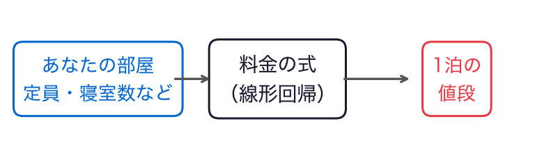

- あなたの部屋に付ける、1泊の値段（円）
- その値段が、まだ見ていない部屋で平均何円外れるか

## 今日の問い

④ 今日の問い●●○○○○

あなたの部屋に、1泊いくらの値段を付ければいいか？

## 今日の山場は欠測値

④ 今日の問い●●●○○○

- いちばん時間をかけるのは、欠測値の扱い
- 欠測した理由を確かめ、補完の方法の良し悪しを評価する

## もう1つのねらい：関数

④ 今日の問い●●●●○○

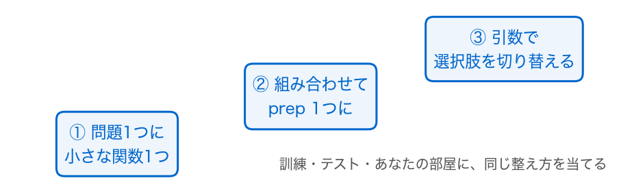

- 前処理を関数（`def`）にまとめ、引数を変えて使いこなせるようになる

## 関数を3段で育てる

④ 今日の問い●●●●●○

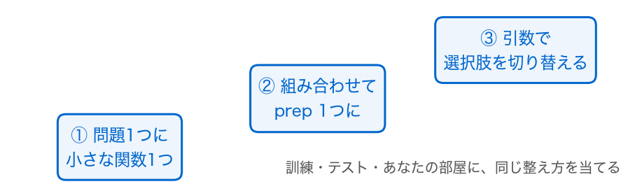

- ①問題を1つ見つけるたびに、小さな関数を1つ書く
- ②組み合わせて`prep`1つにし、③引数で選択肢を切り替える

## 今日の道筋

④ 今日の問い●●●●●●

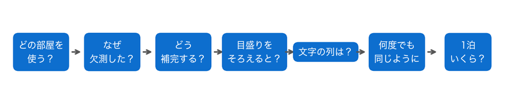

- 前処理を進める順に、7つの小さな問いに答えていく

# 0. 準備

## まずは道具とデータ

- 第3回のノートを開き、上から順にセルを実行する
- 道具を呼び出し、表を読み込んで、列名を日本語にする

## お手本：道具を呼び出す

0節 ① 道具とデータ●○○○

```python
import numpy as np
import pandas as pd
import matplotlib.pyplot as plt
from sklearn.linear_model import LinearRegression
from sklearn.model_selection import train_test_split
```

- `import`は道具箱を持ってくる。`from`は道具箱から1つだけ取り出す
- 図の日本語を表示するセルも、続けて実行する

## お手本：表を読み込む

0節 ① 道具とデータ●●○○

```python
# データはこのリポジトリから読み込む
DATA_DIR = ('https://raw.githubusercontent.com/k0heiun0/'
            'applied_exercise_preview/main/shared/data')
raw = pd.read_csv(f'{DATA_DIR}/airbnb_tokyo.csv')
ja_names = {'neighbourhood': '地区', 'room_type': '部屋のタイプ',
            'property_type': '建物のタイプ', 'accommodates': '定員',
            'bedrooms': '寝室数', 'beds': 'ベッド数',
            'bathrooms': 'バスルーム数',
            'bathrooms_text': 'バスルームの表記',
            'minimum_nights': '最低宿泊数',
            'availability_365': '予約可能日数',
            'number_of_reviews': 'レビュー数',
            'review_scores_rating': 'レビューの点数',
            'reviews_per_month': '月あたりレビュー数',
            'host_is_superhost': 'スーパーホスト',
            'host_listings_count': 'ホストの掲載数', 'price': '料金'}
raw = raw.rename(columns=ja_names)
raw.head()
```

## rawは生のデータ

0節 ① 道具とデータ●●●○

- 辞書`{'元の名前': '新しい名前'}`を`rename`に渡すと、列名を付け替える
- 値は変わらない。変わるのは列名だけ
- 元の表は、あとで何度も使うので`raw`（生のデータ）という名前にする

## 列名が日本語になった

0節 ① 道具とデータ●●●●

|  | 地区 | 部屋のタイプ | 定員 | 寝室数 | ベッド数 | バスルーム数 | バスルームの表記 | 料金 |
| --- | --- | --- | --- | --- | --- | --- | --- | --- |
| 0 | Nishitokyo Shi | Entire home/apt | 11 | 3.0 | 9.0 | 2.0 | 2 baths | 49000 |
| 1 | Kodaira Shi | Entire home/apt | 2 | 1.0 | 1.0 | 1.0 | 1 bath | 9648 |
| 2 | Sumida Ku | Private room | 2 | 1.0 | 1.0 | 1.0 | 1 shared bath | 5500 |
| 3 | Shinjuku Ku | Entire home/apt | 2 | 1.0 | 1.0 | 1.0 | 1 bath | 19100 |
| 4 | Itabashi Ku | Shared room | 1 | NaN | 4.0 | 1.0 | 1 shared bath | 4416 |

- `Entire home/apt`は貸切。`Shinjuku Ku`のような地区の名前は、英語のまま

## やってみよう：0節

0節 ② 確かめる●

- 0節のセルを上から実行し、「セットアップ完了」と表の先頭を確かめる

動画の人は、ここで一時停止。

# 1. どの部屋を相場に入れるか

## どんな部屋が並んでいる？

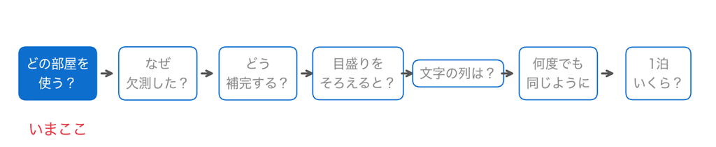

- 値段は、ほかの部屋の料金を手がかりに付ける
- まず、相場に入れる部屋を決める

## お手本：料金の形を見る

1節 ① 料金の形●○○

```python
print(len(raw), '件')
print(raw['料金'].describe().round(0))
plt.hist(raw['料金'], bins=100, range=(0, 300000))
plt.xlabel('1泊の料金（円）')
plt.ylabel('部屋の数')
plt.show()
```

- 役割：料金の要約とヒストグラムを出す
- `range=(0, 300000)`は、図に描く範囲（0〜30万円）を決める引数

## 2万円に山が1つ

1節 ① 料金の形●●○

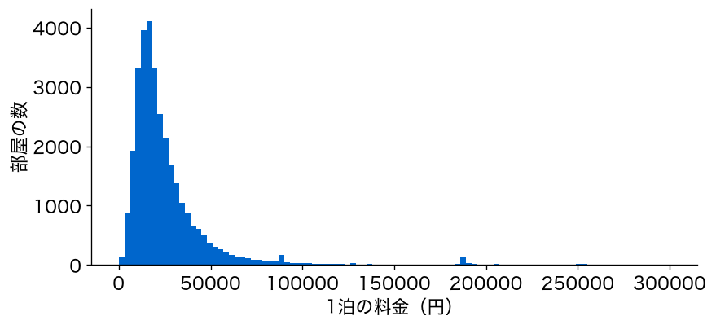

- 2万円あたりに山が1つ。右に長い尾が伸びる

## 最大は545万円

1節 ① 料金の形●●●

```
count      32361.0
mean       31085.0
std        65610.0
min         1514.0
25%        13466.0
50%        19578.0
75%        30430.0
max      5449800.0
```

- 中央値（50%）は約2万円なのに、最大は545万円。尾は図の外まで続く

## 外してよいのか？

1節 ② 外す線●○○○

- 1泊数十万〜数百万円の部屋は、一棟貸しの大きな家や、特定の日の値上げなどが考えられる

## 別の市場と考える

1節 ② 外す線●●○○

- ふつうの部屋とは別の市場。今日の目標の手がかりにならない

## 外すときの約束

1節 ② 外す線●●●○

- 外す理由を、目標から説明できること
- どこで線を引いたかを、書き残すこと

## 1泊10万円以下に絞る

1節 ② 外す線●●●●

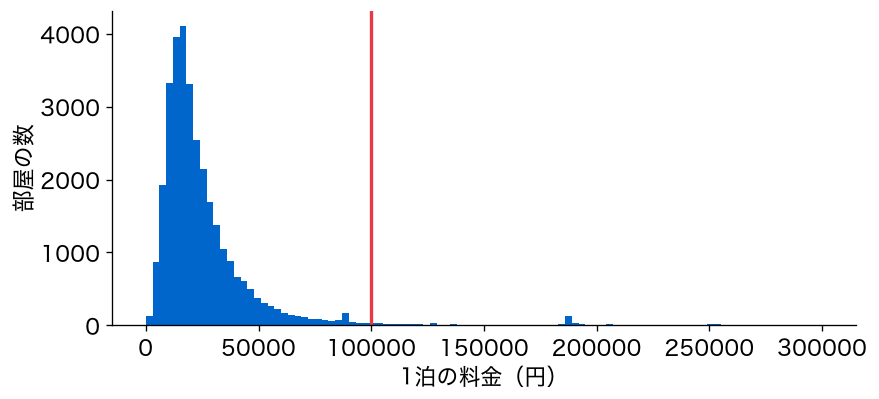

- 赤線より右の、902件（2.8%）を外す

## おさらい：条件で絞る

1節 ③ 貸切に絞る●○○○○○

```python
raw[raw['料金'] <= 100000]      # 10万円以下の部屋だけ
```

- `raw[ ]`にTrue/Falseの並びを入れると、Trueの行だけが残る

## 何を外すか

1節 ③ 貸切に絞る●●○○○○

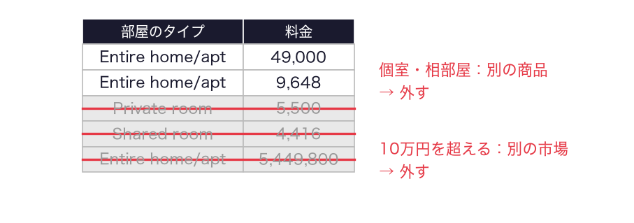

- 個室・相部屋の行と、10万円を超える行を外す
- 残すのは、貸切で10万円以下の行だけ

## 変えてみる：貸切に絞る

1節 ③ 貸切に絞る●●●○○○

```python
df = raw[raw['料金'] <= 100000]                # 10万円以下の部屋だけ
print(len(raw) - len(df), '件を外した')
print(df.groupby('部屋のタイプ')['料金'].agg(['median', 'count']))
df = df[df['部屋のタイプ'] == 'Entire home/apt']  # 貸切の部屋だけ
print(df['最低宿泊数'].isna().sum(), '件は最低宿泊数が欠測している')
df = df[df['最低宿泊数'].notna()]   # その部屋を外す
df = df.reset_index(drop=True)                   # 行の番号を振り直す
print(len(df), '件')
```

## 1行ずつ読む

1節 ③ 貸切に絞る●●●●○○

- `groupby('部屋のタイプ')`でタイプごとに分け、`agg`で料金の中央値と件数を並べる
- `notna()`は、欠測していないマスをTrueにする（3節でくわしく）
- `reset_index(drop=True)`は、行の番号を0から振り直す

## 部屋のタイプで水準が違う

1節 ③ 貸切に絞る●●●●●○

```
902 件を外した
                  median  count
部屋のタイプ
Entire home/apt  20092.0  26433
Hotel room       10875.0    110
Private room     14580.0   4605
Shared room       3424.0    311
```

- 貸切（`Entire home/apt`）は約2万円、相部屋（`Shared room`）は3千円台。別の商品

## 貸切だけで26,430件

1節 ③ 貸切に絞る●●●●●●

```
3 件は最低宿泊数が欠測している
26430 件
```

- 目標に照らして使う行を決めるのも、前処理
- 最低宿泊数が欠測した3件は、理由が分からず数も少ないので外した

## 分けてから整える

1節 ④ 先に分ける●○

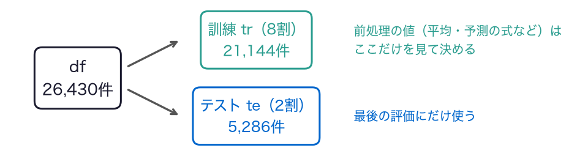

- 整える前に、まず訓練とテストに分ける
- 前処理で使う値は、訓練だけを見て決める

## 先に訓練とテストに分ける

1節 ④ 先に分ける●●

```python
tr, te = train_test_split(df, test_size=0.2, random_state=42)
print(len(tr), len(te))
```

- 訓練21,144件、テスト5,286件
- このあとの前処理は、すべて訓練データだけを見て決める

## やってみよう：1節

1節 ⑤ 確かめる●

- 1節のお手本と「変えてみる」のセルを実行する
- 料金の形と、絞ったあとの件数を確かめる

動画の人は、ここで一時停止。

# 2. 予測の誤差を測る関数

## 何度も測るので関数に

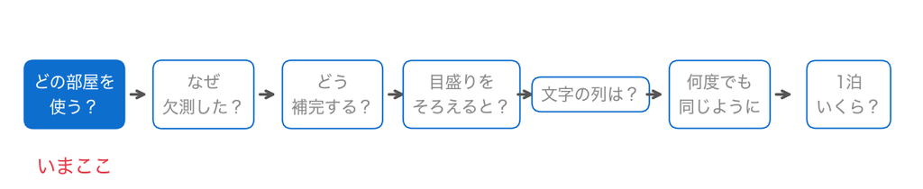

- 今日は、整えるたびに「何円外れるか」を何度も測る
- 同じ計算を毎回書かずに済むよう、関数にする

## MAEを式で

2節 ① defで関数●○○○○

$$\text{MAE} = \frac{1}{n}\sum_{i=1}^{n} \lvert y_i - \hat{y}_i \rvert$$

- $y_i$は$i$番目の部屋の実際の料金、$\hat{y}_i$はその予測
- 差の大きさ$\lvert y_i - \hat{y}_i \rvert$が絶対誤差。その平均が平均絶対誤差（MAE, mean absolute error）

## お手本：MAEを関数に

2節 ① defで関数●●○○○

```python
def mae(y, pred):          # MAE
    return round(np.abs(y - pred).mean())
```

- 役割：実際の料金と予測から、MAE（円）を出す
- `np.abs`は絶対値、`.mean()`は平均、`round`は四捨五入

## defの読み方

2節 ① defで関数●●●○○

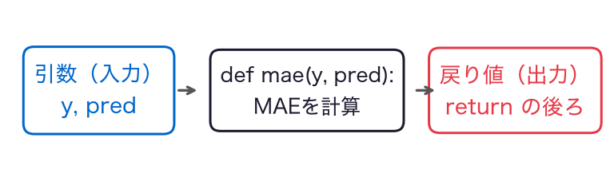

- `def 名前(引数):`で関数を作る。中身は字下げした行
- 引数が入力、`return`の後ろが戻り値（出力）

## 役割・入力・出力に名前を

2節 ① defで関数●●●●○

- これまで「役割・入力・出力」で読んできたかたまり
- それに名前を付けて、何度も呼べるようにしたものが関数

## 作っただけでは何も出ない

2節 ① defで関数●●●●●

- `def`のセルを実行しても、何も表示されない
- 関数を作っただけ。使うには、呼び出す

## 変えてみる：呼び出す

2節 ② 基準を測る●○

```python
base = np.median(tr['料金'])           # 訓練の中央値で答える
print(base)
print(mae(te['料金'], base), '円')     # 関数を呼び出す
```

- 名前にかっこを付け、引数を渡す

## 基準は10,860円

2節 ② 基準を測る●●

```
20009.5
10860 円
```

- どの部屋も約2万円と答えると、MAEは10,860円
- この10,860円を、基準にする

## 式に入れようとすると

2節 ③ 式に入れてみる●○○

```python
cols = ['定員', '寝室数', 'ベッド数', 'バスルーム数', '最低宿泊数',
        '予約可能日数', 'レビュー数', 'ホストの掲載数']
LinearRegression().fit(tr[cols], tr['料金'])
```

- 第2回のように、数の列8本で線形回帰の式を作ろうとすると……

## エラーで止まる

2節 ③ 式に入れてみる●●○

```
ValueError: Input X contains NaN.
```

- いちばん下の行を読む。「手がかりの表Xに、NaNが入っている」
- 欠測のマスがあると、式は作れない

## 欠測をどうにかする

2節 ③ 式に入れてみる●●●

- 欠測をどうにかするのが、次の仕事
- ノートでは、このセルは実行せず、`cols`だけを作っておく

## やってみよう：2節

2節 ④ 確かめる●

- 2節のお手本と「変えてみる」のセルを実行する
- 何も工夫せずに答えると、何円外れるか？

動画の人は、ここで一時停止。

# 3. なぜ欠測したのか

## すぐには補完しない

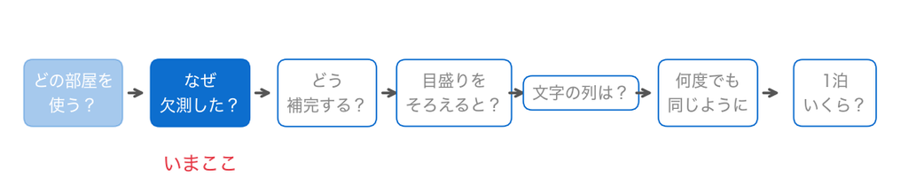

- 欠測があると、式が作れなかった
- 補完する前に、どの列がどれだけ、なぜ欠測したのかを確かめる

## 欠測を数える仕組み

3節 ① 欠測を数える●○○○○

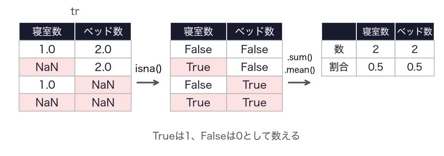

- `isna()`で欠測のマスをTrueにし、列ごとに数える
- 欠測の割合 ＝ 欠測のマスの数 ÷ 行の数 $n$

## TODO①：欠測の数と割合

3節 ① 欠測を数える●●○○○

```python
# TODO: 訓練データ tr の、列ごとの欠測の数と割合（%）を表示する
# ヒント: tr.isna().sum() と tr.isna().mean() * 100
...
```

- `isna()`は、欠測しているマスをTrueにする
- Trueは1として数えるので、`.sum()`で数、`.mean()`で割合

## やってみよう：TODO①

3節 ① 欠測を数える●●●○○

- TODO①：列ごとの欠測の数と割合を出す
- どの列が、どれだけ欠測しているか？

動画の人は、ここで一時停止。

## 答え合わせ：TODO①

3節 ① 欠測を数える●●●●○

```
           欠測の数    割合
寝室数        1025   4.8
ベッド数        838   4.0
バスルーム数     1322   6.3
レビューの点数    2310  10.9
月あたりレビュー数  2310  10.9
```

- 欠測しているのは5つの列。地区や料金は欠測していない
- バスルーム数6.3%、寝室数4.8%、ベッド数4.0%、レビューの点数10.9%

## 欠測の3つのメカニズム

3節 ① 欠測を数える●●●●●

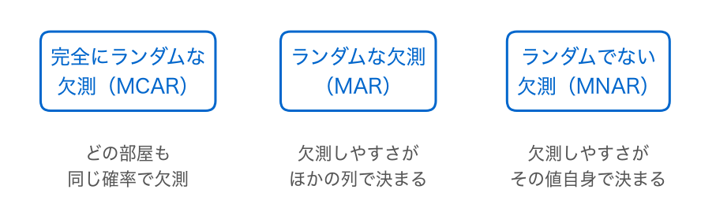

- 欠測のしやすさが何で決まるかで、3つに分ける。これを欠測のメカニズムと呼ぶ
- どれにあたるかで、扱い方が変わる

## お手本：レビューの点数

3節 ② レビューの点数●○○○

```python
no_review = tr['レビュー数'] == 0              # レビューが0件の部屋
no_score = tr['レビューの点数'].isna()        # 点数が欠測した部屋
print(no_review.sum(), no_score.sum())
print((no_review & no_score).sum())          # 両方にあてはまる部屋
```

- `&`は「かつ」。2つの条件の両方がTrueの行を数える

## 3つとも2,310件

3節 ② レビューの点数●●○○

```
2310 2310
2310
```

- 点数が欠測した部屋は、ぴったりレビューが0件の部屋

## 値が存在しない欠測

3節 ② レビューの点数●●●○

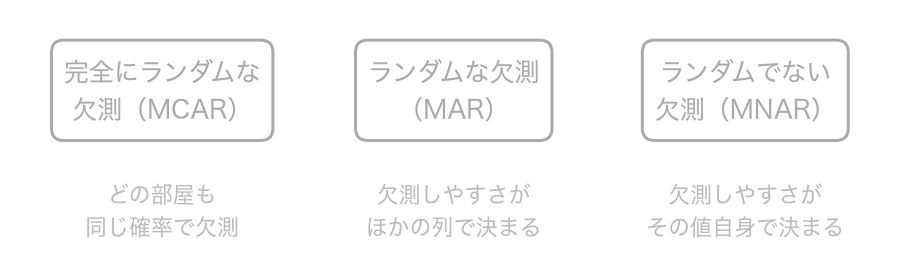

- まだ誰も泊まっていないので、点数が付きようがない
- 3つのメカニズムのどれでもない。値そのものが、はじめから無い

## 補完せずに使わない

3節 ② レビューの点数●●●●

- 平均点で補完すると、泊まった人のいない部屋に、ありもしない点数が付く
- 今日は、点数の列も月あたりレビュー数の列も使わない

## お手本：バスルーム数

3節 ③ バスルーム数●○○○○○○○○○○○○○○

```python
miss = tr['バスルーム数'].isna()      # 欠測した部屋は True
print(miss.sum(), '件')
print(tr[miss]['バスルームの表記'].value_counts())
```

- `value_counts()`は、中身ごとの件数を多い順に並べる

## 表記は全部に書いてある

3節 ③ バスルーム数●●○○○○○○○○○○○○○

```
1322 件
バスルームの表記
1 bath       1072
1.5 baths      95
2 baths        77
0 baths        39
Half-bath      15
3 baths         9
2.5 baths       9
3.5 baths       3
4 baths         2
4.5 baths       1
```

- 欠測した1,322件のどれにも、表記が書いてある。数の列だけが空欄

## 予測より文字から戻す

3節 ③ バスルーム数●●●○○○○○○○○○○○○

- 真の値が、別の列に書いてある
- それなら、予測するより、文字から戻すほうが確か

## 文字を数に直す手順

3節 ③ バスルーム数●●●●○○○○○○○○○○○

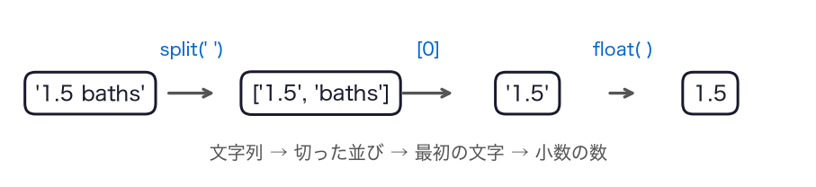

- 3つの操作を順に当てて、文字列を小数の数にする

## 変えてみる：文字1つを数に

3節 ③ バスルーム数●●●●●○○○○○○○○○○

```python
def bath_num(text):            # '1.5 baths' → 1.5
    if text == 'Half-bath':
        return 0.5
    return float(text.split(' ')[0])

print(bath_num('1.5 baths'), bath_num('Half-bath'))  # 確かめる
```

- 役割：表記を1つ受け取り、バスルームの数を返す
- まずは、文字1つを数1つに直す関数だけを作る

## splitで切りfloatで数に

3節 ③ バスルーム数●●●●●●○○○○○○○○○

```python
    return float(text.split(' ')[0])
```

- `'1.5 baths'.split(' ')`は、空白で切って`['1.5', 'baths']`
- `[0]`で最初の`'1.5'`を取り、`float( )`で小数の数1.5にする

## returnで関数は終わる

3節 ③ バスルーム数●●●●●●●○○○○○○○○

```python
    if text == 'Half-bath':
        return 0.5
```

- `'Half-bath'`（半分のバスルーム）だけは数がないので、0.5を返す
- `return`したところで関数は終わる。下の行には進まない

## 1.5と0.5が出た

3節 ③ バスルーム数●●●●●●●●○○○○○○○

```
1.5 0.5
```

- 作った関数は、まず1回呼んで確かめる。1.5と0.5が出れば正しい

## 欠測のマスだけ差し替える

3節 ③ バスルーム数●●●●●●●●●○○○○○○

$$\tilde{x}_i = \begin{cases} x_i & (\text{値がある}) \\ \hat{x}_i & (\text{欠測している}) \end{cases}$$

- 値があれば$x_i$のまま、欠測していれば補完値$\hat{x}_i$にする
- いまの$\hat{x}_i$は、表記から読んだ数

## 表で見ると

3節 ③ バスルーム数●●●●●●●●●●○○○○○

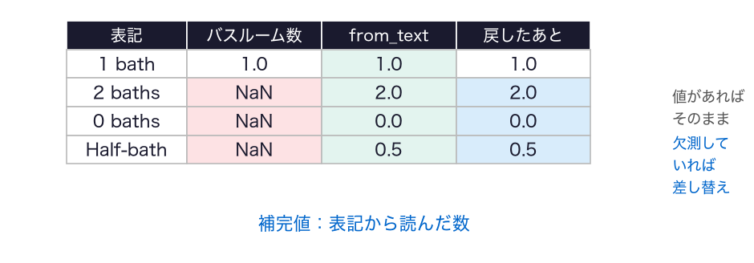

- 補完値の列（緑）を作り、欠測のマス（赤）だけ差し替える（青）

## 変えてみる：表の欠測を戻す

3節 ③ バスルーム数●●●●●●●●●●●○○○○

```python
def fill_bath(df):              # 欠測したバスルーム数を、文字から戻す
    df = df.copy()
    from_text = df['バスルームの表記'].map(bath_num)
    df['バスルーム数'] = df['バスルーム数'].fillna(from_text)
    return df

tr = fill_bath(tr)
te = fill_bath(te)
print(tr['バスルーム数'].isna().sum())
print(te['バスルーム数'].isna().sum())
```

- 役割：表を受け取り、欠測したバスルーム数を表記から戻した表を返す

## mapとfillna

3節 ③ バスルーム数●●●●●●●●●●●●○○○

```python
    from_text = df['バスルームの表記'].map(bath_num)
    df['バスルーム数'] = df['バスルーム数'].fillna(from_text)
```

- `map(関数)`：列の中身を1つずつ関数に通した列を返す
- `fillna(列)`：欠測のマスだけを、同じ行の値で補完する

## copyで元の表を守る

3節 ③ バスルーム数●●●●●●●●●●●●●○○

```python
    df = df.copy()
```

- 受け取った表の写しを作り、写しのほうを書き換える
- 関数の外の表を、知らないうちに書き換えないため（4節で確かめる）

## 欠測は0件になった

3節 ③ バスルーム数●●●●●●●●●●●●●●○

```
0
0
```

- 戻したあとの欠測は、訓練もテストも0件
- その部屋の表記だけを読むので、訓練・テストのどちらに当ててもよい

## この形を覚えておく

3節 ③ バスルーム数●●●●●●●●●●●●●●●

```python
    from_text = df['バスルームの表記'].map(bath_num)
    df['バスルーム数'] = df['バスルーム数'].fillna(from_text)
```

- 補完値の列を作り、`fillna`で欠測のマスだけ差し替える
- このあと、回帰補完するときも同じ形を使う

## 変えてみる：寝室数の欠測

3節 ④ 寝室数とベッド数●○○○○○○

```python
miss_bed = tr['寝室数'].isna()           # 寝室数が欠測した部屋は True
print(tr.groupby(miss_bed)[['定員', '料金']].median())
print('寝室数が0の部屋:', (tr['寝室数'] == 0).sum(), '件')
miss_beds = tr['ベッド数'].isna()        # 欠測した部屋は True
print(tr.groupby(miss_beds)['定員'].median())
```

- True/Falseの並びで`groupby`すると、欠測した部屋と欠測していない部屋に分けて集計できる

## 欠測したのは小さく安い部屋

3節 ④ 寝室数とベッド数●●○○○○○

```
        定員       料金
寝室数
False  4.0  20358.0
True   2.0  15948.0
寝室数が0の部屋: 0 件
```

- 欠測した部屋（True）は定員2人・15,948円。欠測していない部屋は4人・20,358円

## ベッド数も小さい部屋で

3節 ④ 寝室数とベッド数●●●○○○○

```
ベッド数
False    4.0
True     3.0
```

- ベッド数が欠測した部屋（True）も、定員の中央値は3人。欠測していない部屋は4人

## ランダムな欠測（MAR）

3節 ④ 寝室数とベッド数●●●●○○○

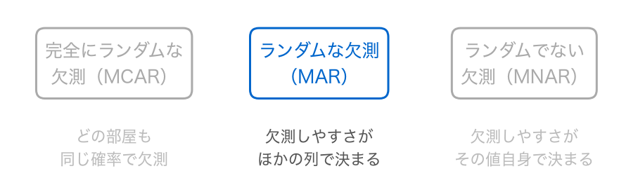

- 定員の小さい部屋ほど、寝室数が欠測しやすい
- 寝室数もベッド数も、小さい部屋で欠測しやすい

## 寝室数0の部屋がない

3節 ④ 寝室数とベッド数●●●●●○○

- 寝室数が0の部屋は、1件もない
- 欠測した部屋は、定員2人の小さい部屋に偏っていた

## ワンルームかもしれない

3節 ④ 寝室数とベッド数●●●●●●○

- ワンルームを、「0」ではなく欠測として登録した部屋が混ざっているのかもしれない
- そうなら、ランダムでない欠測（MNAR）も混ざっている

## 外すと小さい部屋が減る

3節 ④ 寝室数とベッド数●●●●●●●

- 寝室数とベッド数は、料金の手がかりとして使いたい
- 欠測した部屋を外すと、小さい部屋ばかりが減る。だから補完したい

## やってみよう：3節

3節 ⑤ 確かめる●

- 3節のお手本と「変えてみる」のセルを実行する
- 寝室数の欠測が何を意味しそうか、ノートの問いの欄に書く

動画の人は、ここで一時停止。

# 4. 補完の方法を評価する

## 補完した値は当たったか？

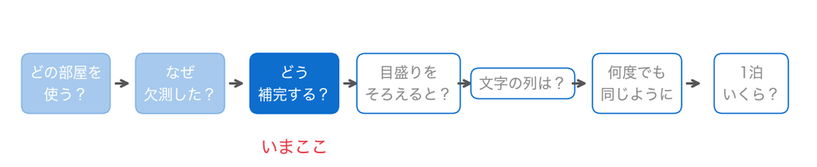

- 寝室数とベッド数は、補完して使いたい
- でも真の値が分からない欠測では、当たったかを確かめられない

## 答えの分かる欠測を作る

4節 ① 欠測を作る●○○○○○○○

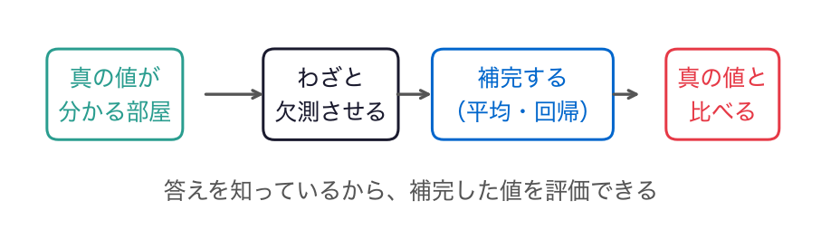

- ベッド数が分かっている部屋から、わざと値を欠測させる
- 答えを知っているので、補完した値を評価できる

## これは練習用のデータ

4節 ① 欠測を作る●●○○○○○○

- 実際の欠測は4%ほど。違いが見えやすいよう、欠測率を上げて欠測させる
- 欠測させ方は実際に合わせる。定員の小さい部屋ほど、多く欠測させる

## 欠測させる確率を式で

4節 ① 欠測を作る●●●○○○○○

$$p_i = \frac{4r}{\text{定員}_i}$$

- $r$は欠測率の目安（`rate`）。定員の小さい部屋ほど$p_i$が大きい
- 部屋ごとに0〜1の乱数を出し、$p_i$より小さければ欠測させる

## 欠測させる部屋を表で見る

4節 ① 欠測を作る●●●●○○○○

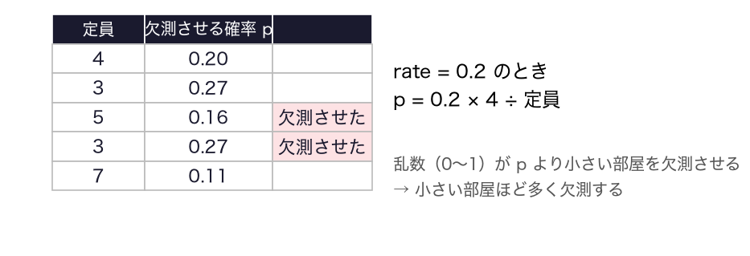

- 訓練の先頭5部屋。定員3人なら0.27、7人なら0.11の確率で欠測させる

## お手本：欠測を作る関数

4節 ① 欠測を作る●●●●●○○○

```python
def make_missing(df, col, rate, seed=0):
    df = df.copy()
    rng = np.random.default_rng(seed)
    hide = rng.random(len(df)) < rate * 4 / df['定員']
    df.loc[hide, col] = np.nan
    return df

full = tr[tr['ベッド数'].notna()]    # ベッド数の分かる部屋
practice = make_missing(full, 'ベッド数', 0.2)
miss = practice['ベッド数'].isna()
print(len(full), '件のうち', miss.sum(), '件を欠測させた')
print(round(miss.mean() * 100, 1), '%')
```

## 既定値つきの引数

4節 ① 欠測を作る●●●●●●○○

```python
def make_missing(df, col, rate, seed=0):
```

- `seed=0`のように`=`で値を書くと、呼び出すときに省けばその値が使われる
- `make_missing(full, 'ベッド数', 0.2)`は、`seed=0`で動く

## 中身は読み飛ばしてよい

4節 ① 欠測を作る●●●●●●●○

```python
    rng = np.random.default_rng(seed)
    hide = rng.random(len(df)) < rate * 4 / df['定員']
    df.loc[hide, col] = np.nan
```

- 練習用の道具。役割・入力・出力と、既定値だけ押さえればよい
- 乱数で、定員の小さい部屋ほど多く選び、そのマスを欠測値`np.nan`にする

## 4,631件を欠測させた

4節 ① 欠測を作る●●●●●●●●

```
20306 件のうち 4631 件を欠測させた
22.8 %
```

- 20,306件のうち、22.8%を欠測させた。真の値は`full`に残っている

## 真の値が残るのはなぜ？

4節 ② copyの役目●○○○○○

- `make_missing`の中では、`df.loc[hide, col] = np.nan`で表を書き換えた
- それでも、渡した`full`には真の値が残っている
- 確かめるため、`df = df.copy()`の行を外してみる

## 変えてみる：copyを外す

4節 ② copyの役目●●○○○○

```python
def make_missing_nc(df, col, rate, seed=0):   # copy の行がない
    rng = np.random.default_rng(seed)
    hide = rng.random(len(df)) < rate * 4 / df['定員']
    df.loc[hide, col] = np.nan
    return df

full_nc = full.copy()              # 壊してよい、試し用の写し
print(full_nc['ベッド数'].isna().sum())
practice_nc = make_missing_nc(full_nc, 'ベッド数', 0.2)
print(full_nc['ベッド数'].isna().sum())
```

- 本物の`full`を壊さないよう、写しの`full_nc`で試す

## 渡した表まで欠測した

4節 ② copyの役目●●●○○○

```
0
4631
```

- 関数に渡しただけの`full_nc`に、4,631件の欠測が入った
- 真の値が消えると、補完した値を評価できない

## 中のdfと外の表は同じもの

4節 ② copyの役目●●●●○○

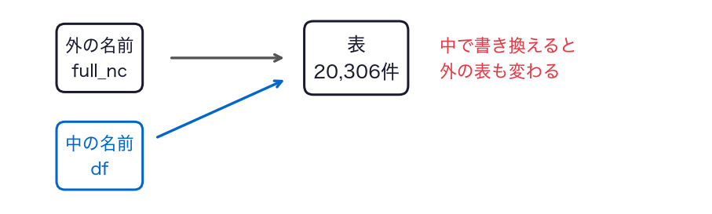

- 表を渡すと、中の`df`と外の`full_nc`は、同じ1つの表を指す
- だから中で書き換えると、外の表も変わる

## copyすれば写しを書き換える

4節 ② copyの役目●●●●●○

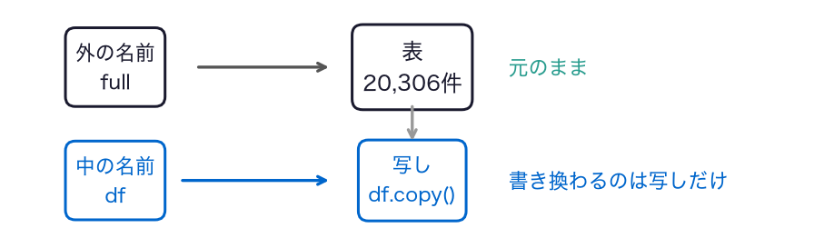

- `df = df.copy()`で写しを作り、`df`をそちらに付け替える
- 書き換わるのは写しだけ。外の`full`は元のまま

## 受け取った表を書き換えるなら

4節 ② copyの役目●●●●●●

- 関数の最初に`df = df.copy()`と書く
- 今日の`fill_bath`・`make_missing`・`fill_reg`は、どれもそうしている

## 平均値補完するとは

4節 ③ 平均値補完する●○○○○○○○○

$$\hat{x}_i = \bar{x} = \frac{1}{|O|}\sum_{k \in O} x_k$$

- $O$は値の残った部屋。その平均$\bar{x}$を、欠測したどの部屋にも入れる
- 補完の式の$\hat{x}_i$が、部屋によらず同じ値になる

## 平均値補完する表

4節 ③ 平均値補完する●●○○○○○○○

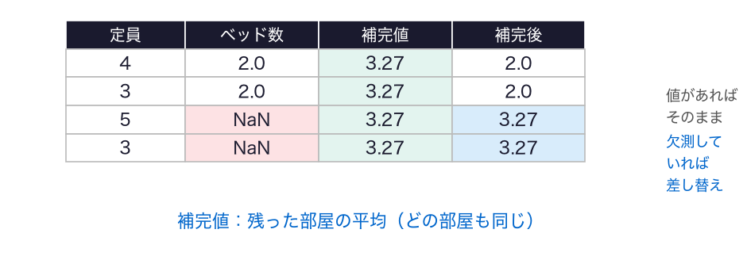

- 定員5人の部屋にも3人の部屋にも、同じ3.27台が入る

## 評価の物差し

4節 ③ 平均値補完する●●●○○○○○○

$$\frac{1}{|M|}\sum_{i \in M} \lvert \tilde{x}_i - x_i \rvert$$

- $M$は欠測させた部屋。補完後の値$\tilde{x}_i$と真の値$x_i$の差の大きさを平均する
- 2節のMAEと同じ形

## お手本：平均値補完する

4節 ③ 平均値補完する●●●●○○○○○

```python
avg = practice['ベッド数'].mean()               # 残った部屋の平均
by_mean = practice['ベッド数'].fillna(avg)      # 欠測を平均値補完する
truth = full['ベッド数']                        # 真の値
print('補完値:', round(avg, 2))
print('MAE:', round(np.abs(by_mean - truth)[miss].mean(), 2), '台')
```

- `fillna(値)`は、欠測のマスを1つの値で置き換える
- `[miss]`で、欠測させた部屋だけの誤差を測る

## MAEは1.63台

4節 ③ 平均値補完する●●●●●○○○○

```
補完値: 3.27
MAE: 1.63 台
```

- 平均3.27台で補完すると、欠測させた部屋でのMAEは1.63台

## どこに入ったか

4節 ③ 平均値補完する●●●●●●○○○

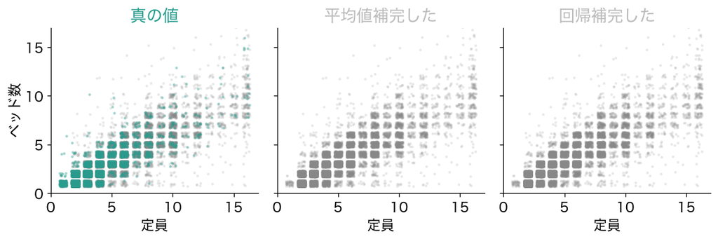

- 真の値（緑が欠測させた部屋）。定員が多いほど、ベッド数も多い
- 点が重ならないよう、少しずらして描いている

## 定員を無視して一直線

4節 ③ 平均値補完する●●●●●●●○○

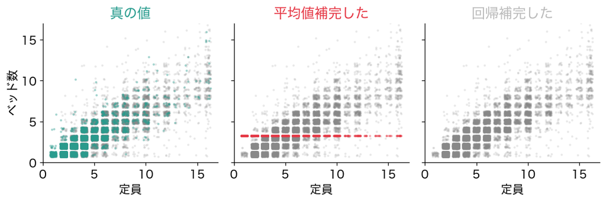

- 平均値補完すると、定員2人の部屋にも8人の部屋にも、同じ3.27台が入る

## おさらい：相関係数

4節 ③ 平均値補完する●●●●●●●●○

$$r = \frac{\sum_i (x_i - \bar{x})(y_i - \bar{y})}{\sqrt{\sum_i (x_i - \bar{x})^2}\,\sqrt{\sum_i (y_i - \bar{y})^2}}$$

- 2つの列の、直線的な関係の強さ。−1〜1
- pandasでは`列1.corr(列2)`で求まる

## 関係も弱まる

4節 ③ 平均値補完する●●●●●●●●●

```python
print('真の値  :', round(full['定員'].corr(truth), 3))
print('平均値補完した:', round(full['定員'].corr(by_mean), 3))
```

```
真の値  : 0.848
平均値補完した: 0.762
```

- 真の相関は0.848。その関係が、0.762まで弱まる

## ほかの列から予測できる

4節 ④ 予測して補完する●○○○○○○

- ベッド数は、定員と強く関係していた
- 定員からベッド数を当てる式を、値の分かる部屋で作れば、欠測した部屋を予測できる

## 予測の式を式で書く

4節 ④ 予測して補完する●●○○○○○

$$\widehat{\text{ベッド数}} = a \times \text{定員} + b$$

- 第2回の線形回帰を、料金ではなくベッド数を当てるのに使う。$a$と$b$は、ベッド数の分かる部屋で決める
- その予測値で補完することを、回帰補完（regression imputation）と呼ぶ

## 回帰補完する表

4節 ④ 予測して補完する●●●○○○○

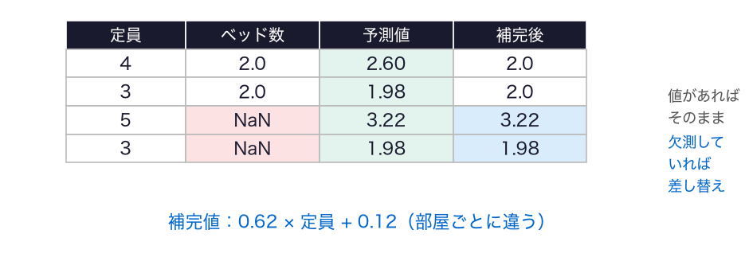

- 予測値の列（緑）は、部屋ごとに違う。欠測のマスだけを差し替える

## お手本：定員から回帰補完する

4節 ④ 予測して補完する●●●●○○○

```python
ok = practice[practice['ベッド数'].notna()]          # 値の分かる部屋
m_bed = LinearRegression().fit(ok[['定員']], ok['ベッド数'])
practice['予測値'] = m_bed.predict(practice[['定員']])
by_reg = practice['ベッド数'].fillna(practice['予測値'])
print('MAE:', round(np.abs(by_reg - truth)[miss].mean(), 2), '台')
print('相関:', round(full['定員'].corr(by_reg), 3))
```

- 役割：値の分かる部屋で式を作り、欠測した部屋をその予測値で補完する

## fill_bathと同じ形

4節 ④ 予測して補完する●●●●●○○

```python
practice['予測値'] = m_bed.predict(practice[['定員']])
by_reg = practice['ベッド数'].fillna(practice['予測値'])
```

- 1行目：どの部屋も、定員から予測する。新しい列名で値を入れると、列が1本増える
- 2行目：`fillna`で、欠測のマスだけを予測値で差し替える
- 3節の`fill_bath`と同じ形

## MAEは0.58台

4節 ④ 予測して補完する●●●●●●○

```
MAE: 0.58 台
相関: 0.863
```

- 平均値補完した1.63台の、3分の1ほど
- 相関も0.863と、真の0.848に近い（少し強めに出る理由は発展で）

## 3つを並べると

4節 ④ 予測して補完する●●●●●●●

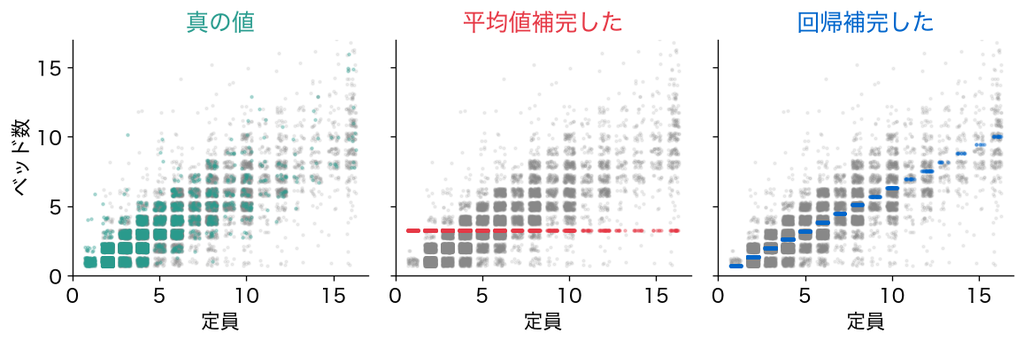

- 予測値（青）は、定員が増えるほど上がる1本の線に乗る
- 平均（赤）のように、定員を無視しない

## gradeの中で起きること

4節 ⑤ 評価を関数に●○○○

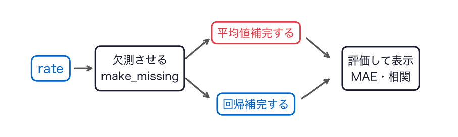

- 欠測率`rate`を受け取り、欠測させる・2通りに補完する・評価する、を通して行う